# R Notebook

loading packages

```r
require(forecast)
require(zoo)
require(DTWBI)
require(openair)
require(stats)
```

importing data

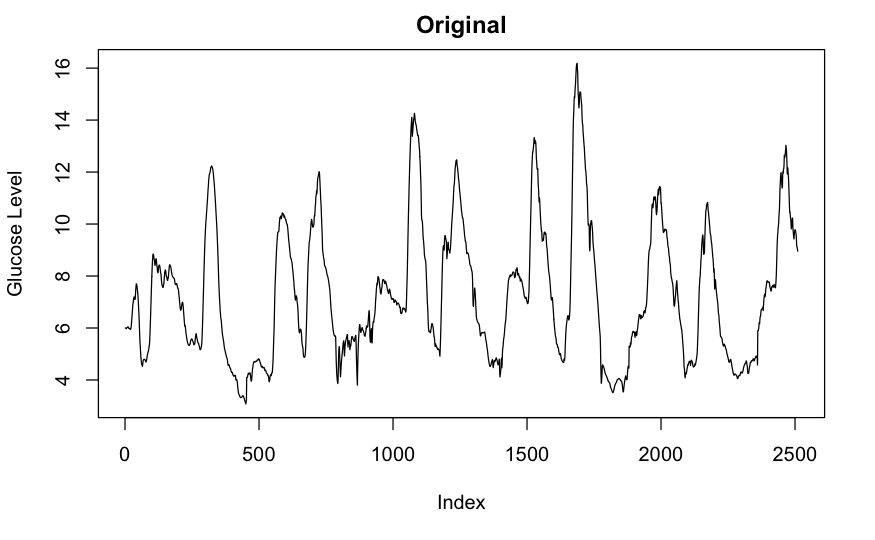

```r
series = read.csv('~/Desktop/NCSA_genomics/CGManalyzer-datasets/ID01.csv')
series$glucoseValue[series$glucoseValue==0.0] <- NA

series = na.omit(series)

plot(series$glucoseValue, type='l', ylab='Glucose Level', main = "Original")
```

converting from mmols to mg/dl

```r
series$glucoseValue = series$glucoseValue*18
```

sampling seed points

```r
seed_points <- sample(1:2400, 1000, replace = FALSE)
#seed_points
```

na.interp error lists for plotting

```r
mad_interp = c()
frac_bias_interp = c()
rmse_interp = c()
ioa_interp = c()
```

Method = {forecast}na.interp Gap = 5

```r
mad_interp_5 = c()
fractional_bias_interp_5 = c()
rmse_interp_5 = c()
ioa_interp_5 = c()


for (i in 1:100) { #runs once for every 5 seed points, i.e., a total of 100 times where i is the seed point
    series_new = series
    old_values = c()
    new_values = c()
    #print("i loop")

    for (k in 0:9) {
      seed = seed_points[i+k]
        for (j in 0:4) { #runs 5 times for every k loop iteration to introduce a gap of 5 starting from a seed point
          old_values = c(old_values,series_new$glucoseValue[seed+j])
          series_new$glucoseValue[seed+j] = NA
        #print("j loop")
      }
    }

    #series_new now has a gap of 5 starting from the seed point, so now we interpolate and get the error for the iteration
    series_new$glucoseValue = na.interp(series_new$glucoseValue)

    for (k in 0:9) {
      seed = seed_points[i+k]
        for (j in 0:4) { #runs 5 times for every k loop iteration to introduce a gap of 5 starting from a seed point
          new_values = c(new_values,series_new$glucoseValue[seed+j])
        #print("j loop")
      }
    }

    #calculating mean absolute difference
    temp1 = mad(new_values)
    mad_interp_5 = c(mad_interp_5,temp1)

    #calculating fractional bias
    temp2 = compute.fb(new_values,old_values)
    fractional_bias_interp_5 = c(fractional_bias_interp_5, temp2)

    #calculating RMSE
    temp3 = compute.rmse(new_values,old_values)
    rmse_interp_5 = c(rmse_interp_5,temp3)

    #calculatind IOA
    x = data.frame("real" = old_values, 'imputed' = new_values)
    temp4 = modStats(x,mod = "imputed",obs = "real", statistic = c("IOA"))
    ioa_interp_5 = c(ioa_interp_5, temp4$IOA)


  }
```

[output not shown]

```r
mean_fractional_bias_interp_5 = mean(fractional_bias_interp_5)
# cat("Mean Fractional Bias for na.interp method with Gap Value of 5 is ",mean_fractional_bias_interp_5, "thats is, ",mean_fractional_bias_interp_5*100,"%\n\n")
#
mean_rmse_interp_5 = mean(rmse_interp_5)
# cat("Mean RMSE for na.interp method with Gap Value of 5 is ",mean_rmse_interp_5, "thats is, ",mean_rmse_interp_5*100,"%\n\n")
#
mean_ioa_interp_5 = mean(ioa_interp_5)
# cat("Mean IOA for na.interp method with Gap Value of 5 is ",mean_ioa_interp_5, "thats is, ",mean_ioa_interp_5*100,"%\n\n")
#
mean_mad_interp_5 = mean(mad_interp_5)
# cat("Mean MAD for na.interp method with Gap Value of 5 is ",mean_mad_interp_5,"\n\n")

mad_interp = c(mad_interp,mean_mad_interp_5)
frac_bias_interp = c(frac_bias_interp,mean_fractional_bias_interp_5)
rmse_interp = c(rmse_interp,mean_rmse_interp_5)
ioa_interp = c(ioa_interp, mean_ioa_interp_5)

rm(temp1)
rm(temp2)
rm(temp3)
rm(temp4)
rm(x)
rm(i)
rm(j)
rm(k)
```

rm(mad_interp_5) rm(mean_mad_interp_5) rm(fractional_bias_interp_5) rm(mean_fractional_bias_interp_5) rm(rmse_interp_5) rm(mean_rmse_interp_5) rm(ioa_interp_5) rm(mean_ioa_interp_5)

Method = {forecast}na.interp Gap = 10

```r
mad_interp_10 = c()
fractional_bias_interp_10 = c()
rmse_interp_10 = c()
ioa_interp_10 = c()


for (i in 1:100) { #runs once for each seed point, i.e., a total of 100 times where i is the seed point
  series_new = series
  old_values = c()
  new_values = c()

  #print("i loop")
   for (k in 0:9) {
      seed = seed_points[i+k]
        for (j in 0:9) { #runs 5 times for every k loop iteration to introduce a gap of 10 starting from a seed point
          old_values = c(old_values,series_new$glucoseValue[seed+j])
        series_new$glucoseValue[seed+j] = NA
        #print("j loop")
      }
    }
  #series_new now has a gap of 10 starting from the seed point, so now we interpolate and get the error for the iteration
  series_new$glucoseValue = na.interp(series_new$glucoseValue)

  for (k in 0:9) {
      seed = seed_points[i+k]
        for (j in 0:9) { #runs 5 times for every k loop iteration to introduce a gap of 5 starting from a seed point
          new_values = c(new_values,series_new$glucoseValue[seed+j])
        #print("j loop")
      }
    }


   #calculating mean absolute difference
  temp1 = mad(new_values)
  mad_interp_10 = c(mad_interp_10,temp1)

  #calculating fractional bias
  temp2 = compute.fb(new_values,old_values)
  fractional_bias_interp_10 = c(fractional_bias_interp_10, temp2)

  #calculating RMSE
  temp3 = compute.rmse(new_values,old_values)
  rmse_interp_10 = c(rmse_interp_10,temp3)

  #calculatind IOA
  x = data.frame("real" = old_values, 'imputed' = new_values)
  temp4 = modStats(x,mod = "imputed",obs = "real", statistic = c("IOA"))
  ioa_interp_10 = c(ioa_interp_10, temp4$IOA)

}
```

[output not shown]

```r
mean_fractional_bias_interp_10 = mean(fractional_bias_interp_10)
# cat("Mean Fractional Bias for na.interp method with Gap Value of 10 is ",mean_fractional_bias_interp_10, "thats is, ",mean_fractional_bias_interp_10*100,"%\n\n")
#
mean_rmse_interp_10 = mean(rmse_interp_10)
# cat("Mean RMSE for na.interp method with Gap Value of 10 is ",mean_rmse_interp_10, "thats is, ",mean_rmse_interp_10*100,"%\n\n")
#
mean_ioa_interp_10 = mean(ioa_interp_10)
# cat("Mean IOA for na.interp method with Gap Value of 10 is ",mean_ioa_interp_10, "thats is, ",mean_ioa_interp_10*100,"%\n\n")
#
mean_mad_interp_10 = mean(mad_interp_10)
# cat("Mean MAD for na.interp method with Gap Value of 10 is ",mean_mad_interp_10,"\n\n")

mad_interp = c(mad_interp,mean_mad_interp_10)
frac_bias_interp = c(frac_bias_interp,mean_fractional_bias_interp_10)
rmse_interp = c(rmse_interp,mean_rmse_interp_10)
ioa_interp = c(ioa_interp, mean_ioa_interp_10)

rm(temp1)
rm(temp2)
rm(temp3)
rm(temp4)
rm(x)
rm(i)
rm(j)
```

rm(mad_interp_10) rm(mean_mad_interp_10) rm(fractional_bias_interp_10) rm(mean_fractional_bias_interp_10) rm(rmse_interp_10) rm(mean_rmse_interp_10) rm(ioa_interp_10) rm(mean_ioa_interp_10)

Method = {forecast}na.interp Gap = 20

```r
mad_interp_20 = c()
fractional_bias_interp_20 = c()
rmse_interp_20 = c()
ioa_interp_20 = c()

for (i in 1:100) { #runs once for each seed point, i.e., a total of 100 times where i is the seed point
  series_new = series
  old_values = c()
new_values = c()

  #print("i loop")
   for (k in 0:9) {
      seed = seed_points[i+k]
        for (j in 0:19) { #runs 20 times for every k loop iteration to introduce a gap of 20 starting from a seed point
          old_values = c(old_values,series_new$glucoseValue[seed+j])
        series_new$glucoseValue[seed+j] = NA
        #print("j loop")
      }
    }
  #series_new now has a gap of 20 starting from the seed point, so now we interpolate and get the error for the iteration
  series_new$glucoseValue = na.interp(series_new$glucoseValue)

  for (k in 0:9) {
      seed = seed_points[i+k]
        for (j in 0:19) { #runs 5 times for every k loop iteration to introduce a gap of 5 starting from a seed point
          new_values = c(new_values,series_new$glucoseValue[seed+j])
        #print("j loop")
      }
    }


  #calculating mean absolute difference
  temp1 = mad(new_values)
  mad_interp_20 = c(mad_interp_20,temp1)

  #calculating fractional bias
  temp2 = compute.fb(new_values,old_values)
  fractional_bias_interp_20 = c(fractional_bias_interp_20, temp2)

  #calculating RMSE
  temp3 = compute.rmse(new_values,old_values)
  rmse_interp_20 = c(rmse_interp_20,temp3)

  #calculatind IOA
  x = data.frame("real" = old_values, 'imputed' = old_values)
  temp4 = modStats(x,mod = "imputed",obs = "real", statistic = c("IOA"))
  ioa_interp_20 = c(ioa_interp_20, temp4$IOA)

}
```

[output not shown]

```r
mean_fractional_bias_interp_20 = mean(fractional_bias_interp_20)
# cat("Mean Fractional Bias for na.interp method with Gap Value of 20 is ",mean_fractional_bias_interp_20, "thats is, ",mean_fractional_bias_interp_20*100,"%\n\n")
#
mean_rmse_interp_20 = mean(rmse_interp_20)
# cat("Mean RMSE for na.interp method with Gap Value of 20 is ",mean_rmse_interp_20, "thats is, ",mean_rmse_interp_20*100,"%\n\n")
#
mean_ioa_interp_20 = mean(ioa_interp_20)
# cat("Mean IOA for na.interp method with Gap Value of 20 is ",mean_ioa_interp_20, "thats is, ",mean_ioa_interp_20*100,"%\n\n")
#
mean_mad_interp_20 = mean(mad_interp_20)
# cat("Mean MAD for na.interp method with Gap Value of 20 is ",mean_mad_interp_20,"\n\n")

mad_interp = c(mad_interp,mean_mad_interp_20)
frac_bias_interp = c(frac_bias_interp,mean_fractional_bias_interp_20)
rmse_interp = c(rmse_interp,mean_rmse_interp_20)
ioa_interp = c(ioa_interp, mean_ioa_interp_20)

rm(temp1)
rm(temp2)
rm(temp3)
rm(temp4)
rm(x)
rm(i)
rm(j)
```

rm(mad_interp_20) rm(mean_mad_interp_20) rm(fractional_bias_interp_20) rm(mean_fractional_bias_interp_20) rm(rmse_interp_20) rm(mean_rmse_interp_20) rm(ioa_interp_20) rm(mean_ioa_interp_20)

Method = {forecast}na.interp Gap = 25

```r
mad_interp_25 = c()
fractional_bias_interp_25 = c()
rmse_interp_25 = c()
ioa_interp_25 = c()

for (i in 1:100) { #runs once for each seed point, i.e., a total of 100 times where i is the seed point
  series_new = series
  old_values = c()
  new_values = c()

  #print("i loop")
   for (k in 0:9) {
      seed = seed_points[i+k]
        for (j in 0:24) { #runs 25 times for every k loop iteration to introduce a gap of 25 starting from a seed point
          old_values = c(old_values,series_new$glucoseValue[seed+j])

        series_new$glucoseValue[seed+j] = NA
        #print("j loop")
      }
    }

  #series_new now has a gap of 25 starting from the seed point, so now we interpolate and get the error for the iteration
  series_new$glucoseValue = na.interp(series_new$glucoseValue)

  for (k in 0:9) {
      seed = seed_points[i+k]
        for (j in 0:24) { #runs 5 times for every k loop iteration to introduce a gap of 5 starting from a seed point
          new_values = c(new_values,series_new$glucoseValue[seed+j])
        #print("j loop")
      }
    }


  #calculating mean absolute difference
  temp1 = mad(new_values)
  mad_interp_25 = c(mad_interp_25,temp1)

  #calculating fractional bias
  temp2 = compute.fb(new_values,old_values)
  fractional_bias_interp_25 = c(fractional_bias_interp_25, temp2)

  #calculating RMSE
  temp3 = compute.rmse(new_values,old_values)
  rmse_interp_25 = c(rmse_interp_25,temp3)

  #calculatind IOA
  x = data.frame("real" = old_values, 'imputed' = new_values)
  temp4 = modStats(x,mod = "imputed",obs = "real", statistic = c("IOA"))
  ioa_interp_25 = c(ioa_interp_25, temp4$IOA)


}
```

[output not shown]

```r
mean_fractional_bias_interp_25 = mean(fractional_bias_interp_25)
# cat("Mean Fractional Bias for na.interp method with Gap Value of 25 is ",mean_fractional_bias_interp_25, "thats is, ",mean_fractional_bias_interp_25*100,"%\n\n")
#
mean_rmse_interp_25 = mean(rmse_interp_25)
# cat("Mean RMSE for na.interp method with Gap Value of 25 is ",mean_rmse_interp_25, "thats is, ",mean_rmse_interp_25*100,"%\n\n")
#
mean_ioa_interp_25 = mean(ioa_interp_25)
# cat("Mean IOA for na.interp method with Gap Value of 25 is ",mean_ioa_interp_25, "thats is, ",mean_ioa_interp_25*100,"%\n\n")
#
mean_mad_interp_25 = mean(mad_interp_25)
# cat("Mean MAD for na.interp method with Gap Value of 25 is ",mean_mad_interp_25,"\n\n")

mad_interp = c(mad_interp,mean_mad_interp_25)
frac_bias_interp = c(frac_bias_interp,mean_fractional_bias_interp_25)
rmse_interp = c(rmse_interp,mean_rmse_interp_25)
ioa_interp = c(ioa_interp, mean_ioa_interp_25)

rm(temp1)
rm(temp2)
rm(temp3)
rm(temp4)
rm(x)
rm(i)
rm(j)
```

rm(mad_interp_25) rm(mean_mad_interp_25) rm(fractional_bias_interp_25) rm(mean_fractional_bias_interp_25) rm(rmse_interp_25) rm(mean_rmse_interp_25) rm(ioa_interp_25) rm(mean_ioa_interp_25)

Method = {forecast}na.interp Gap = 50

```r
mad_interp_50 = c()
fractional_bias_interp_50 = c()
rmse_interp_50 = c()
ioa_interp_50 = c()

for (i in 1:100) { #runs once for each seed point, i.e., a total of 100 times where i is the seed point
  series_new = series
  old_values = c()
  new_values = c()

  #print("i loop")
   for (k in 0:9) {
      seed = seed_points[i+k]
        for (j in 0:49) { #runs 50 times for every k loop iteration to introduce a gap of 50 starting from a seed point
         old_values = c(old_values,series_new$glucoseValue[seed+j])
        series_new$glucoseValue[seed+j] = NA
        #print("j loop")
      }
    }

  #series_new now has a gap of 50 starting from the seed point, so now we interpolate and get the error for the iteration
  series_new$glucoseValue = na.interp(series_new$glucoseValue)

  for (k in 0:9) {
      seed = seed_points[i+k]
        for (j in 0:49) { #runs 5 times for every k loop iteration to introduce a gap of 5 starting from a seed point
          new_values = c(new_values,series_new$glucoseValue[seed+j])
        #print("j loop")
      }
    }


  #calculating mean absolute difference
  temp1 = mad(new_values)
  mad_interp_50 = c(mad_interp_50,temp1)

  #calculating fractional bias
  temp2 = compute.fb(new_values,old_values)
  fractional_bias_interp_50 = c(fractional_bias_interp_50, temp2)

  #calculating RMSE
  temp3 = compute.rmse(new_values,old_values)
  rmse_interp_50 = c(rmse_interp_50,temp3)

  #calculatind IOA
  x = data.frame("real" = old_values, 'imputed' = new_values)
  temp4 = modStats(x,mod = "imputed",obs = "real", statistic = c("IOA"))
  ioa_interp_50 = c(ioa_interp_50, temp4$IOA)

}
```

[output not shown]

```r
mean_fractional_bias_interp_50 = mean(fractional_bias_interp_50)
# cat("Mean Fractional Bias for na.interp method with Gap Value of 50 is ",mean_fractional_bias_interp_50, "thats is, ",mean_fractional_bias_interp_50*100,"%\n\n")
#
mean_rmse_interp_50 = mean(rmse_interp_50)
# cat("Mean RMSE for na.interp method with Gap Value of 50 is ",mean_rmse_interp_50, "thats is, ",mean_rmse_interp_50*100,"%\n\n")
#
mean_ioa_interp_50 = mean(ioa_interp_50)
# cat("Mean IOA for na.interp method with Gap Value of 50 is ",mean_ioa_interp_50, "thats is, ",mean_ioa_interp_50*100,"%\n\n")
#
mean_mad_interp_50 = mean(mad_interp_50)
# cat("Mean MAD for na.interp method with Gap Value of 50 is ",mean_mad_interp_50,"\n\n")

mad_interp = c(mad_interp,mean_mad_interp_50)
frac_bias_interp = c(frac_bias_interp,mean_fractional_bias_interp_50)
rmse_interp = c(rmse_interp,mean_rmse_interp_50)
ioa_interp = c(ioa_interp, mean_ioa_interp_50)

rm(temp1)
rm(temp2)
rm(temp3)
rm(temp4)
rm(x)
rm(i)
rm(j)
```

rm(mad_interp_50) rm(mean_mad_interp_50) rm(fractional_bias_interp_50) rm(mean_fractional_bias_interp_50) rm(rmse_interp_50) rm(mean_rmse_interp_50) rm(ioa_interp_50) rm(mean_ioa_interp_50)

Method = {forecast}na.interp Gap = 100

```r
mad_interp_100 = c()
fractional_bias_interp_100 = c()
rmse_interp_100 = c()
ioa_interp_100 = c()

for (i in 1:100) { #runs once for each seed point, i.e., a total of 100 times where i is the seed point
  series_new = series
  old_values = c()
new_values = c()

  #print("i loop")

   for (k in 0:9) {
      seed = seed_points[i+k]
        for (j in 0:99) { #runs 100 times for every k loop iteration to introduce a gap of 100 starting from a seed point
          old_values = c(old_values,series_new$glucoseValue[seed+j])
        series_new$glucoseValue[seed+j] = NA
        #print("j loop")
      }
   }


  #series_new now has a gap of 50 starting from the seed point, so now we interpolate and get the error for the iteration
  series_new$glucoseValue = na.interp(series_new$glucoseValue)

  for (k in 0:9) {
      seed = seed_points[i+k]
        for (j in 0:99) { #runs 5 times for every k loop iteration to introduce a gap of 5 starting from a seed point
          new_values = c(new_values,series_new$glucoseValue[seed+j])
        #print("j loop")
      }
    }


  #calculating mean absolute difference
  temp1 = mad(new_values)
  mad_interp_100 = c(mad_interp_100,temp1)

  #calculating fractional bias
  temp2 = compute.fb(new_values,old_values)
  fractional_bias_interp_100 = c(fractional_bias_interp_100, temp2)

  #calculating RMSE
  temp3 = compute.rmse(new_values,old_values)
  rmse_interp_100 = c(rmse_interp_100,temp3)

  #calculatind IOA
  x = data.frame("real" = old_values, 'imputed' = new_values)
  temp4 = modStats(x,mod = "imputed",obs = "real", statistic = c("IOA"))
  ioa_interp_100 = c(ioa_interp_100, temp4$IOA)

}
```

[output not shown]

```r
mean_fractional_bias_interp_100 = mean(fractional_bias_interp_100)
# cat("Mean Fractional Bias for na.interp method with Gap Value of 100 is ",mean_fractional_bias_interp_100, "thats is, ",mean_fractional_bias_interp_100*100,"%\n\n")
#
mean_rmse_interp_100 = mean(rmse_interp_100)
# cat("Mean RMSE for na.interp method with Gap Value of 100 is ",mean_rmse_interp_100, "thats is, ",mean_rmse_interp_100*100,"%\n\n")
#
mean_ioa_interp_100 = mean(ioa_interp_100)
# cat("Mean IOA for na.interp method with Gap Value of 100 is ",mean_ioa_interp_100, "thats is, ",mean_ioa_interp_100*100,"%\n\n")
#
mean_mad_interp_100 = mean(mad_interp_100)
# cat("Mean MAD for na.interp method with Gap Value of 100 is ",mean_mad_interp_100,"\n\n")

mad_interp = c(mad_interp,mean_mad_interp_100)
frac_bias_interp = c(frac_bias_interp,mean_fractional_bias_interp_100)
rmse_interp = c(rmse_interp,mean_rmse_interp_100)
ioa_interp = c(ioa_interp, mean_ioa_interp_100)

rm(temp1)
rm(temp2)
rm(temp3)
rm(temp4)
rm(x)
rm(i)
rm(j)
```

rm(mad_interp_100) rm(mean_mad_interp_100) rm(fractional_bias_interp_100) rm(mean_fractional_bias_interp_100) rm(rmse_interp_100) rm(mean_rmse_interp_100) rm(ioa_interp_100) rm(mean_ioa_interp_100)

na.interp final values

```r
# mad_interp
# frac_bias_interp
# rmse_interp
# ioa_interp
```

na.approx error lists for plotting

```r
mad_approx = c()
frac_bias_approx = c()
rmse_approx = c()
ioa_approx = c()
```

Method = {zoo}na.approx Gap = 5

```r
mad_approx_5 = c()
fractional_bias_approx_5 = c()
rmse_approx_5 = c()
ioa_approx_5 = c()

for (i in 1:100) { #runs once for each seed point, i.e., a total of 100 times where i is the seed point
series_new = series
  old_values = c()
new_values = c()

  print("i loop")
   for (k in 0:9) {
      seed = seed_points[i+k]
        for (j in 0:4) { #runs 5 times for every k loop iteration to introduce a gap of 5 starting from a seed point
          old_values = c(old_values,series_new$glucoseValue[seed+j])

        series_new$glucoseValue[seed+j] = NA
        #print("j loop")
      }
    }
  #series_new now has a gap of 5 starting from the seed point, so now we approximate and get the error for the iteration

  w = na.approx(series_new$glucoseValue)

  for (k in 0:9) {
      seed = seed_points[i+k]
        for (j in 0:4) { #runs 5 times for every k loop iteration to introduce a gap of 5 starting from a seed point
          new_values = c(new_values,w[seed+j])
        #print("j loop")
      }
    }


  #calculating mean absolute difference
  temp1 = mad(new_values)
  mad_approx_5 = c(mad_approx_5,temp1)

  #calculating fractional bias
  temp2 = compute.fb(new_values,old_values)
  fractional_bias_approx_5 = c(fractional_bias_approx_5, temp2)

  #calculating RMSE
  temp3 = compute.rmse(new_values,old_values)
  rmse_approx_5 = c(rmse_approx_5,temp3)

  #calculatind IOA
  x = data.frame("real" = old_values, 'imputed' = new_values)
  temp4 = modStats(x,mod = "imputed",obs = "real", statistic = c("IOA"))
  ioa_approx_5 = c(ioa_approx_5, temp4$IOA)

  print("hello")


}
```

[output not shown]

[output not shown]

[output not shown]

[output not shown]

[output not shown]

[output not shown]

[output not shown]

[output not shown]

[output not shown]

[output not shown]

[output not shown]

[output not shown]

[output not shown]

[output not shown]

[output not shown]

[output not shown]

[output not shown]

[output not shown]

[output not shown]

[output cut: 41 more lines]

[output not shown]

[output not shown]

[output not shown]

[output not shown]

[output not shown]

[output not shown]

[output not shown]

[output not shown]

[output not shown]

[output not shown]

[output not shown]

[output not shown]

[output not shown]

[output not shown]

[output not shown]

[output not shown]

[output not shown]

[output not shown]

[output not shown]

[output not shown]

[output not shown]

[output not shown]

[output not shown]

[output not shown]

[output not shown]

[output not shown]

[output not shown]

[output not shown]

[output not shown]

[output not shown]

[output not shown]

[output not shown]

[output not shown]

[output not shown]

[output not shown]

[output not shown]

[output not shown]

[output not shown]

[output not shown]

[output not shown]

[output not shown]

[output not shown]

[output not shown]

[output not shown]

[output not shown]

[output not shown]

[output cut: 38 more lines]

```r
mean_fractional_bias_approx_5 = mean(fractional_bias_approx_5)
# cat("Mean Fractional Bias for na.approx method with Gap Value of 5 is ",mean_fractional_bias_approx_5, "thats is, ",mean_fractional_bias_approx_5*100,"%\n\n")
#
mean_rmse_approx_5 = mean(rmse_approx_5)
# cat("Mean RMSE for na.approx method with Gap Value of 5 is ",mean_rmse_approx_5, "thats is, ",mean_rmse_approx_5*100,"%\n\n")
#
mean_ioa_approx_5 = mean(ioa_approx_5)
# cat("Mean IOA for na.approx method with Gap Value of 5 is ",mean_ioa_approx_5, "thats is, ",mean_ioa_approx_5*100,"%\n\n")
#
mean_mad_approx_5 = mean(mad_approx_5)
# cat("Mean MAD for na.approx method with Gap Value of 5 is ",mean_mad_approx_5,"\n\n")
#
mad_approx = c(mad_approx,mean_mad_approx_5)
frac_bias_approx = c(frac_bias_approx,mean_fractional_bias_approx_5)
rmse_approx = c(rmse_approx,mean_rmse_approx_5)
ioa_approx = c(ioa_approx, mean_ioa_approx_5)

rm(temp1)
rm(temp2)
rm(temp3)
rm(temp4)
rm(x)
rm(i)
rm(j)
rm(w)
```

rm(mad_approx_5) rm(mean_mad_approx_5) rm(fractional_bias_approx_5) rm(mean_fractional_bias_approx_5) rm(rmse_approx_5) rm(mean_rmse_approx_5) rm(ioa_approx_5) rm(mean_ioa_approx_5)

Method = {zoo}na.approx Gap = 10

```r
mad_approx_10 = c()
fractional_bias_approx_10 = c()
rmse_approx_10 = c()
ioa_approx_10 = c()

for (i in 1:100) { #runs once for each seed point, i.e., a total of 100 times where i is the seed point
  series_new = series
  old_values = c()
new_values = c()

  #print("i loop")

   for (k in 0:9) {
      seed = seed_points[i+k]
        for (j in 0:9) { #runs 5 times for every k loop iteration to introduce a gap of 5 starting from a seed point
          old_values = c(old_values,series_new$glucoseValue[seed+j])
        series_new$glucoseValue[seed+j] = NA
        #print("j loop")
      }
   }


  #series_new now has a gap of 10 starting from the seed point, so now we approximate and get the error for the iteration
  w = na.approx(series_new$glucoseValue)

  for (k in 0:9) {
      seed = seed_points[i+k]
        for (j in 0:9) { #runs 5 times for every k loop iteration to introduce a gap of 5 starting from a seed point
          new_values = c(new_values,w[seed+j])
        #print("j loop")
      }
    }


  #calculating mean absolute difference
  temp1 = mad(new_values)
  mad_approx_10 = c(mad_approx_10,temp1)

  #calculating fractional bias
  temp2 = compute.fb(new_values,old_values)
  fractional_bias_approx_10 = c(fractional_bias_approx_10, temp2)

  #calculating RMSE
  temp3 = compute.rmse(new_values,old_values)
  rmse_approx_10 = c(rmse_approx_10,temp3)

  #calculatind IOA
  x = data.frame("real" = old_values, 'imputed' = new_values)
  temp4 = modStats(x,mod = "imputed",obs = "real", statistic = c("IOA"))
  ioa_approx_10 = c(ioa_approx_10, temp4$IOA)


}
```

[output not shown]

```r
mean_fractional_bias_approx_10 = mean(fractional_bias_approx_10)
# cat("Mean Fractional Bias for na.approx method with Gap Value of 10 is ",mean_fractional_bias_approx_10, "thats is, ",mean_fractional_bias_approx_10*100,"%\n\n")
#
mean_rmse_approx_10 = mean(rmse_approx_10)
# cat("Mean RMSE for na.approx method with Gap Value of 10 is ",mean_rmse_approx_10, "thats is, ",mean_rmse_approx_10*100,"%\n\n")
#
mean_ioa_approx_10 = mean(ioa_approx_10)
# cat("Mean IOA for na.approx method with Gap Value of 10 is ",mean_ioa_approx_10, "thats is, ",mean_ioa_approx_10*100,"%\n\n")
#
mean_mad_approx_10 = mean(mad_approx_10)
# cat("Mean MAD for na.approx method with Gap Value of 10 is ",mean_mad_approx_10,"\n\n")
#
mad_approx = c(mad_approx,mean_mad_approx_10)
frac_bias_approx = c(frac_bias_approx,mean_fractional_bias_approx_10)
rmse_approx = c(rmse_approx,mean_rmse_approx_10)
ioa_approx = c(ioa_approx, mean_ioa_approx_10)

rm(temp1)
rm(temp2)
rm(temp3)
rm(temp4)
rm(x)
rm(i)
rm(j)
rm(w)
```

rm(mad_approx_10) rm(mean_mad_approx_10) rm(fractional_bias_approx_10) rm(mean_fractional_bias_approx_10) rm(rmse_approx_10) rm(mean_rmse_approx_10) rm(ioa_approx_10) rm(mean_ioa_approx_10)

Method = {zoo}na.approx Gap = 20

```r
mad_approx_20 = c()
fractional_bias_approx_20 = c()
rmse_approx_20 = c()
ioa_approx_20 = c()

for (i in 1:100) { #runs once for each seed point, i.e., a total of 100 times where i is the seed point
  series_new = series
  old_values = c()
new_values = c()

  #print("i loop")
   for (k in 0:9) {
      seed = seed_points[i+k]
        for (j in 0:19) { #runs 5 times for every k loop iteration to introduce a gap of 5 starting from a seed point
          old_values = c(old_values,series_new$glucoseValue[seed+j])

        series_new$glucoseValue[seed+j] = NA
        #print("j loop")
      }
   }


  #series_new now has a gap of 20 starting from the seed point, so now we approximate and get the error for the iteration
  w = na.approx(series_new$glucoseValue)

  for (k in 0:9) {
      seed = seed_points[i+k]
        for (j in 0:19) { #runs 5 times for every k loop iteration to introduce a gap of 5 starting from a seed point
          new_values = c(new_values,w[seed+j])
        #print("j loop")
      }
    }


  #calculating mean absolute difference
  temp1 = mad(new_values)
  mad_approx_20 = c(mad_approx_20,temp1)

  #calculating fractional bias
  temp2 = compute.fb(new_values,old_values)
  fractional_bias_approx_20 = c(fractional_bias_approx_20, temp2)

  #calculating RMSE
  temp3 = compute.rmse(new_values,old_values)
  rmse_approx_20 = c(rmse_approx_20,temp3)

  #calculatind IOA
  x = data.frame("real" = old_values, 'imputed' = new_values)
  temp4 = modStats(x,mod = "imputed",obs = "real", statistic = c("IOA"))
  ioa_approx_20 = c(ioa_approx_20, temp4$IOA)


}
```

[output not shown]

```r
mean_fractional_bias_approx_20 = mean(fractional_bias_approx_20)
# cat("Mean Fractional Bias for na.approx method with Gap Value of 20 is ",mean_fractional_bias_approx_20, "thats is, ",mean_fractional_bias_approx_20*100,"%\n\n")
#
mean_rmse_approx_20 = mean(rmse_approx_20)
# cat("Mean RMSE for na.approx method with Gap Value of 20 is ",mean_rmse_approx_20, "thats is, ",mean_rmse_approx_20*100,"%\n\n")
#
mean_ioa_approx_20 = mean(ioa_approx_20)
# cat("Mean IOA for na.approx method with Gap Value of 20 is ",mean_ioa_approx_20, "thats is, ",mean_ioa_approx_20*100,"%\n\n")
#
mean_mad_approx_20 = mean(mad_approx_20)
# cat("Mean MAD for na.approx method with Gap Value of 20 is ",mean_mad_approx_20,"\n\n")
#
mad_approx = c(mad_approx,mean_mad_approx_20)
frac_bias_approx = c(frac_bias_approx,mean_fractional_bias_approx_20)
rmse_approx = c(rmse_approx,mean_rmse_approx_20)
ioa_approx = c(ioa_approx, mean_ioa_approx_20)

rm(temp1)
rm(temp2)
rm(temp3)
rm(temp4)
rm(x)
rm(i)
rm(j)
rm(w)
```

rm(mad_approx_20) rm(mean_mad_approx_20) rm(fractional_bias_approx_20) rm(mean_fractional_bias_approx_20) rm(rmse_approx_20) rm(mean_rmse_approx_20) rm(ioa_approx_20) rm(mean_ioa_approx_20)

Method = {zoo}na.approx Gap = 25

```r
mad_approx_25 = c()
fractional_bias_approx_25 = c()
rmse_approx_25 = c()
ioa_approx_25 = c()

for (i in 1:100) { #runs once for each seed point, i.e., a total of 100 times where i is the seed point
  series_new = series
  old_values = c()
new_values = c()

  #print("i loop")
   for (k in 0:9) {
      seed = seed_points[i+k]
        for (j in 0:24) { #runs 5 times for every k loop iteration to introduce a gap of 5 starting from a seed point
          old_values = c(old_values,series_new$glucoseValue[seed+j])

        series_new$glucoseValue[seed+j] = NA
        #print("j loop")
      }
   }


  #series_new now has a gap of 5 starting from the seed point, so now we approximate and get the error for the iteration
 w = na.approx(series_new$glucoseValue)

  for (k in 0:9) {
      seed = seed_points[i+k]
        for (j in 0:24) { #runs 5 times for every k loop iteration to introduce a gap of 5 starting from a seed point
          new_values = c(new_values,w[seed+j])
        #print("j loop")
      }
    }


  #calculating mean absolute difference
  temp1 = mad(new_values)
  mad_approx_25 = c(mad_approx_25,temp1)

  #calculating fractional bias
  temp2 = compute.fb(new_values,old_values)
  fractional_bias_approx_25 = c(fractional_bias_approx_25, temp2)

  #calculating RMSE
  temp3 = compute.rmse(new_values,old_values)
  rmse_approx_25 = c(rmse_approx_25,temp3)

  #calculatind IOA
  x = data.frame("real" = old_values, 'imputed' = new_values)
  temp4 = modStats(x,mod = "imputed",obs = "real", statistic = c("IOA"))
  ioa_approx_25 = c(ioa_approx_25, temp4$IOA)


}
```

[output not shown]

```r
mean_fractional_bias_approx_25 = mean(fractional_bias_approx_25)
# cat("Mean Fractional Bias for na.approx method with Gap Value of 25 is ",mean_fractional_bias_approx_25, "thats is, ",mean_fractional_bias_approx_25*100,"%\n\n")
#
mean_rmse_approx_25 = mean(rmse_approx_25)
# cat("Mean RMSE for na.approx method with Gap Value of 25 is ",mean_rmse_approx_25, "thats is, ",mean_rmse_approx_25*100,"%\n\n")
#
mean_ioa_approx_25 = mean(ioa_approx_25)
# cat("Mean IOA for na.approx method with Gap Value of 25 is ",mean_ioa_approx_25, "thats is, ",mean_ioa_approx_25*100,"%\n\n")
#
mean_mad_approx_25 = mean(mad_approx_25)
# cat("Mean MAD for na.approx method with Gap Value of 25 is ",mean_mad_approx_25,"\n\n")
#
mad_approx = c(mad_approx,mean_mad_approx_25)
frac_bias_approx = c(frac_bias_approx,mean_fractional_bias_approx_25)
rmse_approx = c(rmse_approx,mean_rmse_approx_25)
ioa_approx = c(ioa_approx, mean_ioa_approx_25)

rm(temp1)
rm(temp2)
rm(temp3)
rm(temp4)
rm(x)
rm(i)
rm(j)
rm(w)
```

rm(mad_approx_25) rm(mean_mad_approx_25) rm(fractional_bias_approx_25) rm(mean_fractional_bias_approx_25) rm(rmse_approx_25) rm(mean_rmse_approx_25) rm(ioa_approx_25) rm(mean_ioa_approx_25)

Method = {zoo}na.approx Gap = 50

```r
mad_approx_50 = c()
fractional_bias_approx_50 = c()
rmse_approx_50 = c()
ioa_approx_50 = c()
for (i in 1:100) { #runs once for each seed point, i.e., a total of 100 times where i is the seed point
  series_new = series
  old_values = c()
new_values = c()

  #print("i loop")
   for (k in 0:9) {
      seed = seed_points[i+k]
        for (j in 0:49) { #runs 5 times for every k loop iteration to introduce a gap of 5 starting from a seed point
          old_values = c(old_values,series_new$glucoseValue[seed+j])
        series_new$glucoseValue[seed+j] = NA
        #print("j loop")
      }
   }


  #series_new now has a gap of 50 starting from the seed point, so now we approximate and get the error for the iteration
  w = na.approx(series_new$glucoseValue)

  for (k in 0:9) {
      seed = seed_points[i+k]
        for (j in 0:49) { #runs 5 times for every k loop iteration to introduce a gap of 5 starting from a seed point
          new_values = c(new_values,w[seed+j])
        #print("j loop")
      }
    }


  #calculating mean absolute difference
  temp1 = mad(new_values)
  mad_approx_50 = c(mad_approx_50,temp1)

  #calculating fractional bias
  temp2 = compute.fb(new_values,old_values)
  fractional_bias_approx_50 = c(fractional_bias_approx_50, temp2)

  #calculating RMSE
  temp3 = compute.rmse(new_values,old_values)
  rmse_approx_50 = c(rmse_approx_50,temp3)

  #calculatind IOA
  x = data.frame("real" = old_values, 'imputed' = new_values)
  temp4 = modStats(x,mod = "imputed",obs = "real", statistic = c("IOA"))
  ioa_approx_50 = c(ioa_approx_50, temp4$IOA)


}
```

[output not shown]

```r
mean_fractional_bias_approx_50 = mean(fractional_bias_approx_50)
# cat("Mean Fractional Bias for na.approx method with Gap Value of 50 is ",mean_fractional_bias_approx_50, "thats is, ",mean_fractional_bias_approx_50*100,"%\n\n")
#
mean_rmse_approx_50 = mean(rmse_approx_50)
# cat("Mean RMSE for na.approx method with Gap Value of 50 is ",mean_rmse_approx_50, "thats is, ",mean_rmse_approx_50*100,"%\n\n")
#
mean_ioa_approx_50 = mean(ioa_approx_50)
# cat("Mean IOA for na.approx method with Gap Value of 50 is ",mean_ioa_approx_50, "thats is, ",mean_ioa_approx_50*100,"%\n\n")
#
mean_mad_approx_50 = mean(mad_approx_50)
# cat("Mean MAD for na.approx method with Gap Value of 50 is ",mean_mad_approx_50,"\n\n")
#
mad_approx = c(mad_approx,mean_mad_approx_50)
frac_bias_approx = c(frac_bias_approx,mean_fractional_bias_approx_50)
rmse_approx = c(rmse_approx,mean_rmse_approx_50)
ioa_approx = c(ioa_approx, mean_ioa_approx_50)

rm(temp1)
rm(temp2)
rm(temp3)
rm(temp4)
rm(x)
rm(i)
rm(j)
rm(w)
```

rm(mad_approx_50) rm(mean_mad_approx_50) rm(fractional_bias_approx_50) rm(mean_fractional_bias_approx_50) rm(rmse_approx_50) rm(mean_rmse_approx_50) rm(ioa_approx_50) rm(mean_ioa_approx_50)

Method = {zoo}na.approx Gap = 100

```r
mad_approx_100 = c()
fractional_bias_approx_100 = c()
rmse_approx_100 = c()
ioa_approx_100 = c()
for (i in 1:100) { #runs once for each seed point, i.e., a total of 100 times where i is the seed point
  series_new = series
  old_values = c()
new_values = c()

  #print("i loop")
   for (k in 0:9) {
      seed = seed_points[i+k]
        for (j in 0:99) { #runs 5 times for every k loop iteration to introduce a gap of 5 starting from a seed point
          old_values = c(old_values,series_new$glucoseValue[seed+j])
        series_new$glucoseValue[seed+j] = NA
        #print("j loop")
      }
    }

  #series_new now has a gap of 10 starting from the seed point, so now we approximate and get the error for the iteration
  w = na.approx(series_new$glucoseValue)

   for (k in 0:9) {
      seed = seed_points[i+k]
        for (j in 0:99) { #runs 5 times for every k loop iteration to introduce a gap of 5 starting from a seed point
          new_values = c(new_values,w[seed+j])
        #print("j loop")
      }
    }


  #calculating mean absolute difference
  temp1 = mad(new_values)
  mad_approx_100 = c(mad_approx_100,temp1)

  #calculating fractional bias
  temp2 = compute.fb(new_values,old_values)
  fractional_bias_approx_100 = c(fractional_bias_approx_100, temp2)

  #calculating RMSE
  temp3 = compute.rmse(new_values,old_values)
  rmse_approx_100 = c(rmse_approx_100,temp3)

  #calculatind IOA
  x = data.frame("real" = old_values, 'imputed' = new_values)
  temp4 = modStats(x,mod = "imputed",obs = "real", statistic = c("IOA"))
  ioa_approx_100 = c(ioa_approx_100, temp4$IOA)


}
```

[output not shown]

```r
mean_fractional_bias_approx_100 = mean(fractional_bias_approx_100)
# cat("Mean Fractional Bias for na.approx method with Gap Value of 100 is ",mean_fractional_bias_approx_100, "thats is, ",mean_fractional_bias_approx_100*100,"%\n\n")
#
mean_rmse_approx_100 = mean(rmse_approx_100)
# cat("Mean RMSE for na.approx method with Gap Value of 100 is ",mean_rmse_approx_100, "thats is, ",mean_rmse_approx_100*100,"%\n\n")
#
mean_ioa_approx_100 = mean(ioa_approx_100)
# cat("Mean IOA for na.approx method with Gap Value of 100 is ",mean_ioa_approx_100, "thats is, ",mean_ioa_approx_100*100,"%\n\n")
#
mean_mad_approx_100 = mean(mad_approx_100)
# cat("Mean MAD for na.approx method with Gap Value of 100 is ",mean_mad_approx_100,"\n\n")
#
mad_approx = c(mad_approx,mean_mad_approx_100)
frac_bias_approx = c(frac_bias_approx,mean_fractional_bias_approx_100)
rmse_approx = c(rmse_approx,mean_rmse_approx_100)
ioa_approx = c(ioa_approx, mean_ioa_approx_100)

rm(temp1)
rm(temp2)
rm(temp3)
rm(temp4)
rm(x)
rm(i)
rm(j)
rm(w)
```

rm(mad_approx_100) rm(mean_mad_approx_100) rm(fractional_bias_approx_100) rm(mean_fractional_bias_approx_100) rm(rmse_approx_100) rm(mean_rmse_approx_100) rm(ioa_approx_100) rm(mean_ioa_approx_100)

na.approx final values

```r
# mad_approx
# frac_bias_approx
# rmse_approx
# ioa_approx
```

na.spline error lists for plotting

```r
mad_spline = c()
frac_bias_spline = c()
rmse_spline = c()
ioa_spline = c()
```

Method = {zoo}na.spline Gap = 5

```r
mad_spline_5 = c()
fractional_bias_spline_5 = c()
rmse_spline_5 = c()
ioa_spline_5 = c()

for (i in 1:100) { #runs once for each seed point, i.e., a total of 100 times where i is the seed point
  series_new = series
  old_values = c()
new_values = c()

  #print("i loop")
   for (k in 0:9) {
      seed = seed_points[i+k]
        for (j in 0:4) { #runs 5 times for every k loop iteration to introduce a gap of 5 starting from a seed point
          old_values = c(old_values,series_new$glucoseValue[seed+j])

        series_new$glucoseValue[seed+j] = NA
        #print("j loop")
      }
    }

  #series_new now has a gap of 5 starting from the seed point, so now we spline and get the error for the iteration
  series_new$glucoseValue = na.spline(series_new$glucoseValue)

  for (k in 0:9) {
      seed = seed_points[i+k]
        for (j in 0:4) { #runs 5 times for every k loop iteration to introduce a gap of 5 starting from a seed point
          new_values = c(new_values,series_new$glucoseValue[seed+j])
        #print("j loop")
      }
    }


  #calculating mean absolute difference
  temp1 = mad(new_values)
  mad_spline_5 = c(mad_spline_5,temp1)

  #calculating fractional bias
  temp2 = compute.fb(new_values,old_values)
  fractional_bias_spline_5 = c(fractional_bias_spline_5, temp2)

  #calculating RMSE
  temp3 = compute.rmse(new_values,old_values)
  rmse_spline_5 = c(rmse_spline_5,temp3)

  #calculatind IOA
  x = data.frame("real" = old_values, 'imputed' = new_values)
  temp4 = modStats(x,mod = "imputed",obs = "real", statistic = c("IOA"))
  ioa_spline_5 = c(ioa_spline_5, temp4$IOA)


}
```

[output not shown]

```r
mean_fractional_bias_spline_5 = mean(fractional_bias_spline_5)
# cat("Mean Fractional Bias for na.spline method with Gap Value of 5 is ",mean_fractional_bias_spline_5, "thats is, ",mean_fractional_bias_spline_5*100,"%\n\n")
#
mean_rmse_spline_5 = mean(rmse_spline_5)
# cat("Mean RMSE for na.spline method with Gap Value of 5 is ",mean_rmse_spline_5, "thats is, ",mean_rmse_spline_5*100,"%\n\n")
#
mean_ioa_spline_5 = mean(ioa_spline_5)
# cat("Mean IOA for na.spline method with Gap Value of 5 is ",mean_ioa_spline_5, "thats is, ",mean_ioa_spline_5*100,"%\n\n")
#
mean_mad_spline_5 = mean(mad_spline_5)
# cat("Mean MAD for na.approx method with Gap Value of 5 is ",mean_mad_spline_5,"\n\n")
#
mad_spline = c(mad_spline,mean_mad_spline_5)
frac_bias_spline = c(frac_bias_spline,mean_fractional_bias_spline_5)
rmse_spline = c(rmse_spline,mean_rmse_spline_5)
ioa_spline = c(ioa_spline, mean_ioa_spline_5)

rm(temp1)
rm(temp2)
rm(temp3)
rm(temp4)
rm(x)
rm(i)
rm(j)
```

rm(mad_spline_5) rm(mean_mad_spline_5) rm(fractional_bias_spline_5) rm(mean_fractional_bias_spline_5) rm(rmse_spline_5) rm(mean_rmse_spline_5) rm(ioa_spline_5) rm(mean_ioa_spline_5)

Method = {zoo}na.spline Gap = 10

```r
mad_spline_10 = c()
fractional_bias_spline_10 = c()
rmse_spline_10 = c()
ioa_spline_10 = c()

for (i in 1:100) { #runs once for each seed point, i.e., a total of 100 times where i is the seed point
  series_new = series
  old_values = c()
new_values = c()

  #print("i loop")
   for (k in 0:9) {
      seed = seed_points[i+k]
        for (j in 0:9) { #runs 5 times for every k loop iteration to introduce a gap of 5 starting from a seed point
          old_values = c(old_values,series_new$glucoseValue[seed+j])

        series_new$glucoseValue[seed+j] = NA
        #print("j loop")
      }
    }

  #series_new now has a gap of 10 starting from the seed point, so now we spline and get the error for the iteration
  series_new$glucoseValue = na.spline(series_new$glucoseValue)

  for (k in 0:9) {
      seed = seed_points[i+k]
        for (j in 0:9) { #runs 5 times for every k loop iteration to introduce a gap of 5 starting from a seed point
          new_values = c(new_values,series_new$glucoseValue[seed+j])
        #print("j loop")
      }
    }


  #calculating mean absolute difference
  temp1 = mad(new_values)
  mad_spline_10 = c(mad_spline_10,temp1)

  #calculating fractional bias
  temp2 = compute.fb(new_values,old_values)
  fractional_bias_spline_10 = c(fractional_bias_spline_10, temp2)

  #calculating RMSE
  temp3 = compute.rmse(new_values,old_values)
  rmse_spline_10 = c(rmse_spline_10,temp3)

  #calculatind IOA
  x = data.frame("real" = old_values, 'imputed' = new_values)
  temp4 = modStats(x,mod = "imputed", obs = "real", statistic = c("IOA"))
  ioa_spline_10 = c(ioa_spline_10, temp4$IOA)


}
```

[output not shown]

```r
mean_fractional_bias_spline_10 = mean(fractional_bias_spline_10)
# cat("Mean Fractional Bias for na.spline method with Gap Value of 10 is ",mean_fractional_bias_spline_10, "thats is, ",mean_fractional_bias_spline_10*100,"%\n\n")
#
mean_rmse_spline_10 = mean(rmse_spline_10)
# cat("Mean RMSE for na.spline method with Gap Value of 10 is ",mean_rmse_spline_10, "thats is, ",mean_rmse_spline_10*100,"%\n\n")
#
mean_ioa_spline_10 = mean(ioa_spline_10)
# cat("Mean IOA for na.spline method with Gap Value of 10 is ",mean_ioa_spline_10, "thats is, ",mean_ioa_spline_10*100,"%\n\n")
#
mean_mad_spline_10 = mean(mad_spline_10)
# cat("Mean MAD for na.approx method with Gap Value of 10 is ",mean_mad_spline_10,"\n\n")
#
mad_spline = c(mad_spline,mean_mad_spline_10)
frac_bias_spline = c(frac_bias_spline,mean_fractional_bias_spline_10)
rmse_spline = c(rmse_spline,mean_rmse_spline_10)
ioa_spline = c(ioa_spline, mean_ioa_spline_10)

rm(temp1)
rm(temp2)
rm(temp3)
rm(temp4)
rm(x)
rm(i)
rm(j)
```

rm(mad_spline_10) rm(mean_mad_spline_10) rm(fractional_bias_spline_10) rm(mean_fractional_bias_spline_10) rm(rmse_spline_10) rm(mean_rmse_spline_10) rm(ioa_spline_10) rm(mean_ioa_spline_10)

Method = {zoo}na.spline Gap = 20

```r
mad_spline_20 = c()
fractional_bias_spline_20 = c()
rmse_spline_20 = c()
ioa_spline_20 = c()

for (i in 1:100) { #runs once for each seed point, i.e., a total of 100 times where i is the seed point
  series_new = series
  old_values = c()
new_values = c()

  #print("i loop")
   for (k in 0:9) {
      seed = seed_points[i+k]
        for (j in 0:19) { #runs 5 times for every k loop iteration to introduce a gap of 5 starting from a seed point
          old_values = c(old_values,series_new$glucoseValue[seed+j])

        series_new$glucoseValue[seed+j] = NA
        #print("j loop")
      }
   }


  #series_new now has a gap of 20 starting from the seed point, so now we spline and get the error for the iteration
  series_new$glucoseValue = na.spline(series_new$glucoseValue)

  for (k in 0:9) {
      seed = seed_points[i+k]
        for (j in 0:19) { #runs 5 times for every k loop iteration to introduce a gap of 5 starting from a seed point
          new_values = c(new_values,series_new$glucoseValue[seed+j])
        #print("j loop")
      }
    }


  #calculating mean absolute difference
  temp1 = mad(new_values)
  mad_spline_20 = c(mad_spline_20,temp1)

  #calculating fractional bias
  temp2 = compute.fb(new_values,old_values)
  fractional_bias_spline_20 = c(fractional_bias_spline_20, temp2)

  #calculating RMSE
  temp3 = compute.rmse(new_values,old_values)
  rmse_spline_20 = c(rmse_spline_20,temp3)

  #calculatind IOA
  x = data.frame("real" = old_values, 'imputed' = new_values)
  temp4 = modStats(x,mod = "imputed",obs = "real", statistic = c("IOA"))
  ioa_spline_20 = c(ioa_spline_20, temp4$IOA)


}
```

[output not shown]

```r
mean_fractional_bias_spline_20 = mean(fractional_bias_spline_20)
# cat("Mean Fractional Bias for na.spline method with Gap Value of 20 is ",mean_fractional_bias_spline_20, "thats is, ",mean_fractional_bias_spline_20*100,"%\n\n")
#
mean_rmse_spline_20 = mean(rmse_spline_20)
# cat("Mean RMSE for na.spline method with Gap Value of 20 is ",mean_rmse_spline_20, "thats is, ",mean_rmse_spline_20*100,"%\n\n")
#
mean_ioa_spline_20 = mean(ioa_spline_20)
# cat("Mean IOA for na.spline method with Gap Value of 20 is ",mean_ioa_spline_20, "thats is, ",mean_ioa_spline_20*100,"%\n\n")
#
mean_mad_spline_20 = mean(mad_spline_20)
# cat("Mean MAD for na.approx method with Gap Value of 20 is ",mean_mad_spline_20,"\n\n")
#
mad_spline = c(mad_spline,mean_mad_spline_20)
frac_bias_spline = c(frac_bias_spline,mean_fractional_bias_spline_20)
rmse_spline = c(rmse_spline,mean_rmse_spline_20)
ioa_spline = c(ioa_spline, mean_ioa_spline_20)

rm(temp1)
rm(temp2)
rm(temp3)
rm(temp4)
rm(x)
rm(i)
rm(j)
```

rm(mad_spline_20) rm(mean_mad_spline_20) rm(fractional_bias_spline_20) rm(mean_fractional_bias_spline_20) rm(rmse_spline_20) rm(mean_rmse_spline_20) rm(ioa_spline_20) rm(mean_ioa_spline_20)

Method = {zoo}na.spline Gap = 25

```r
mad_spline_25 = c()
fractional_bias_spline_25 = c()
rmse_spline_25 = c()
ioa_spline_25 = c()
for (i in 1:100) { #runs once for each seed point, i.e., a total of 100 times where i is the seed point
  series_new = series
  old_values = c()
new_values = c()

  #print("i loop")
   for (k in 0:9) {
      seed = seed_points[i+k]
        for (j in 0:24) { #runs 5 times for every k loop iteration to introduce a gap of 5 starting from a seed point
          old_values = c(old_values,series_new$glucoseValue[seed+j])

        series_new$glucoseValue[seed+j] = NA
        #print("j loop")
      }
    }

  #series_new now has a gap of 20 starting from the seed point, so now we spline and get the error for the iteration
  series_new$glucoseValue = na.spline(series_new$glucoseValue)

  for (k in 0:9) {
      seed = seed_points[i+k]
        for (j in 0:24) { #runs 5 times for every k loop iteration to introduce a gap of 5 starting from a seed point
          new_values = c(new_values,series_new$glucoseValue[seed+j])
        #print("j loop")
      }
    }


  #calculating mean absolute difference
  temp1 = mad(new_values)
  mad_spline_25 = c(mad_spline_25,temp1)

  #calculating fractional bias
  temp2 = compute.fb(new_values,old_values)
  fractional_bias_spline_25 = c(fractional_bias_spline_25, temp2)

  #calculating RMSE
  temp3 = compute.rmse(new_values,old_values)
  rmse_spline_25 = c(rmse_spline_25,temp3)

  #calculatind IOA
  x = data.frame("real" = old_values, 'imputed' = new_values)
  temp4 = modStats(x,mod = "imputed",obs = "real", statistic = c("IOA"))
  ioa_spline_25 = c(ioa_spline_25, temp4$IOA)


}
```

[output not shown]

```r
mean_fractional_bias_spline_25 = mean(fractional_bias_spline_25)
# cat("Mean Fractional Bias for na.spline method with Gap Value of 25 is ",mean_fractional_bias_spline_25, "thats is, ",mean_fractional_bias_spline_25*100,"%\n\n")
#
mean_rmse_spline_25 = mean(rmse_spline_25)
# cat("Mean RMSE for na.spline method with Gap Value of 25 is ",mean_rmse_spline_25, "thats is, ",mean_rmse_spline_25*100,"%\n\n")
#
mean_ioa_spline_25 = mean(ioa_spline_25)
# cat("Mean IOA for na.spline method with Gap Value of 25 is ",mean_ioa_spline_25, "thats is, ",mean_ioa_spline_25*100,"%\n\n")
#
mean_mad_spline_25 = mean(mad_spline_25)
# cat("Mean MAD for na.approx method with Gap Value of 25 is ",mean_mad_spline_25,"\n\n")
#
mad_spline = c(mad_spline,mean_mad_spline_25)
frac_bias_spline = c(frac_bias_spline,mean_fractional_bias_spline_25)
rmse_spline = c(rmse_spline,mean_rmse_spline_25)
ioa_spline = c(ioa_spline, mean_ioa_spline_25)

rm(temp1)
rm(temp2)
rm(temp3)
rm(temp4)
rm(x)
rm(i)
rm(j)
```

rm(mad_spline_25) rm(mean_mad_spline_25) rm(fractional_bias_spline_25) rm(mean_fractional_bias_spline_25) rm(rmse_spline_25) rm(mean_rmse_spline_25) rm(ioa_spline_25) rm(mean_ioa_spline_25)

Method = {zoo}na.spline Gap = 50

```r
mad_spline_50 = c()
fractional_bias_spline_50 = c()
rmse_spline_50 = c()
ioa_spline_50 = c()

for (i in 1:100) { #runs once for each seed point, i.e., a total of 100 times where i is the seed point
  series_new = series
  old_values = c()
new_values = c()

  #print("i loop")
   for (k in 0:9) {
      seed = seed_points[i+k]
        for (j in 0:49) { #runs 5 times for every k loop iteration to introduce a gap of 5 starting from a seed point
          old_values = c(old_values,series_new$glucoseValue[seed+j])

        series_new$glucoseValue[seed+j] = NA
        #print("j loop")
      }
   }


  #series_new now has a gap of 50 starting from the seed point, so now we spline and get the error for the iteration
  series_new$glucoseValue = na.spline(series_new$glucoseValue)

  for (k in 0:9) {
      seed = seed_points[i+k]
        for (j in 0:49) { #runs 5 times for every k loop iteration to introduce a gap of 5 starting from a seed point
          new_values = c(new_values,series_new$glucoseValue[seed+j])
        #print("j loop")
      }
    }


  #calculating mean absolute difference
  temp1 = mad(new_values)
  mad_spline_50 = c(mad_spline_50,temp1)

  #calculating fractional bias
  temp2 = compute.fb(new_values,old_values)
  fractional_bias_spline_50 = c(fractional_bias_spline_50, temp2)

  #calculating RMSE
  temp3 = compute.rmse(new_values,old_values)
  rmse_spline_50 = c(rmse_spline_50,temp3)

  #calculatind IOA
  x = data.frame("real" = old_values, 'imputed' = new_values)
  temp4 = modStats(x,mod = "imputed",obs = "real", statistic = c("IOA"))
  ioa_spline_50 = c(ioa_spline_50, temp4$IOA)


}
```

[output not shown]

```r
mean_fractional_bias_spline_50 = mean(fractional_bias_spline_50)
# cat("Mean Fractional Bias for na.spline method with Gap Value of 50 is ",mean_fractional_bias_spline_50, "thats is, ",mean_fractional_bias_spline_50*100,"%\n\n")
#
mean_rmse_spline_50 = mean(rmse_spline_50)
# cat("Mean RMSE for na.spline method with Gap Value of 50 is ",mean_rmse_spline_50, "thats is, ",mean_rmse_spline_50*100,"%\n\n")
#
mean_ioa_spline_50 = mean(ioa_spline_50)
# cat("Mean IOA for na.spline method with Gap Value of 50 is ",mean_ioa_spline_50, "thats is, ",mean_ioa_spline_50*100,"%\n\n")
#
mean_mad_spline_50 = mean(mad_spline_50)
# cat("Mean MAD for na.approx method with Gap Value of 50 is ",mean_mad_spline_50,"\n\n")
#
mad_spline = c(mad_spline,mean_mad_spline_50)
frac_bias_spline = c(frac_bias_spline,mean_fractional_bias_spline_50)
rmse_spline = c(rmse_spline,mean_rmse_spline_50)
ioa_spline = c(ioa_spline, mean_ioa_spline_50)

rm(temp1)
rm(temp2)
rm(temp3)
rm(temp4)
rm(x)
rm(i)
rm(j)
```

rm(mad_spline_50) rm(mean_mad_spline_50) rm(fractional_bias_spline_50) rm(mean_fractional_bias_spline_50) rm(rmse_spline_50) rm(mean_rmse_spline_50) rm(ioa_spline_50) rm(mean_ioa_spline_50)

Method = {zoo}na.spline Gap = 100

```r
mad_spline_100 = c()
fractional_bias_spline_100 = c()
rmse_spline_100 = c()
ioa_spline_100 = c()

for (i in 1:100) { #runs once for each seed point, i.e., a total of 100 times where i is the seed point
  series_new = series
  old_values = c()
new_values = c()

  #print("i loop")
   for (k in 0:9) {
      seed = seed_points[i+k]
        for (j in 0:99) { #runs 5 times for every k loop iteration to introduce a gap of 5 starting from a seed point
          old_values = c(old_values,series_new$glucoseValue[seed+j])

        series_new$glucoseValue[seed+j] = NA
        #print("j loop")
      }
   }


#plot(series_new$glucoseValue, type='l', ylab='Glucose Level')

  #series_new now has a gap of 10 starting from the seed point, so now we spline and get the error for the iteration
  series_new$glucoseValue = na.spline(series_new$glucoseValue)

  for (k in 0:9) {
      seed = seed_points[i+k]
        for (j in 0:99) { #runs 5 times for every k loop iteration to introduce a gap of 5 starting from a seed point
          new_values = c(new_values,series_new$glucoseValue[seed+j])
        #print("j loop")
      }
    }


  #calculating mean absolute difference
  temp1 = mad(series_new$glucoseValue)
  mad_spline_100 = c(mad_spline_100,temp1)

  #calculating fractional bias
  temp2 = compute.fb(series_new$glucoseValue,series$glucoseValue)
  fractional_bias_spline_100 = c(fractional_bias_spline_100, temp2)

  #calculating RMSE
  temp3 = compute.rmse(series_new$glucoseValue,series$glucoseValue)
  rmse_spline_100 = c(rmse_spline_100,temp3)

  #calculatind IOA
  x = data.frame("real" = series$glucoseValue, 'imputed' = series_new$glucoseValue)
  temp4 = modStats(x,mod = "imputed", obs = "real", statistic = c("IOA"))
  ioa_spline_100 = c(ioa_spline_100, temp4$IOA)


}


mean_fractional_bias_spline_100 = mean(fractional_bias_spline_100)
# cat("Mean Fractional Bias for na.spline method with Gap Value of 100 is ",mean_fractional_bias_spline_100, "thats is, ",mean_fractional_bias_spline_100*100,"%\n\n")
#
mean_rmse_spline_100 = mean(rmse_spline_100)
# cat("Mean RMSE for na.spline method with Gap Value of 100 is ",mean_rmse_spline_100, "thats is, ",mean_rmse_spline_100*100,"%\n\n")
#
mean_ioa_spline_100 = mean(ioa_spline_100)
# cat("Mean IOA for na.spline method with Gap Value of 100 is ",mean_ioa_spline_100, "thats is, ",mean_ioa_spline_100*100,"%\n\n")
#
mean_mad_spline_100 = mean(mad_spline_100)
# cat("Mean MAD for na.approx method with Gap Value of 100 is ",mean_mad_spline_100,"\n\n")
#
mad_spline = c(mad_spline,mean_mad_spline_100)
frac_bias_spline = c(frac_bias_spline,mean_fractional_bias_spline_100)
rmse_spline = c(rmse_spline,mean_rmse_spline_100)
ioa_spline = c(ioa_spline, mean_ioa_spline_100)

rm(temp1)
rm(temp2)
rm(temp3)
rm(temp4)
rm(x)
rm(i)
rm(j)
```

rm(mad_spline_100) rm(mean_mad_spline_100) rm(fractional_bias_spline_100) rm(mean_fractional_bias_spline_100) rm(rmse_spline_100) rm(mean_rmse_spline_100) rm(ioa_spline_100) rm(mean_ioa_spline_100)

na.spline error lists for plotting

```r
# mad_spline
# frac_bias_spline
# rmse_spline
# ioa_spline
```

Compating fractional biases for all three methods

```r
l=c('5','10','20','25','50','100')
plot(NULL,NULL, xaxt='n', xlim = c(1,6), ylim = c(-2,2),xlab = 'Gap Size', ylab = 'Fractional Bias', main = 'Comparing Fractional Bias')
axis(1,at=seq(1:6),labels = l)
```

```r
legend("topleft", c('na.approx', 'na.interp', 'na.spline'), col = c('red','blue','green'),lwd=2,cex=.75)
lines(frac_bias_approx, col = 'red',lwd=6)
```

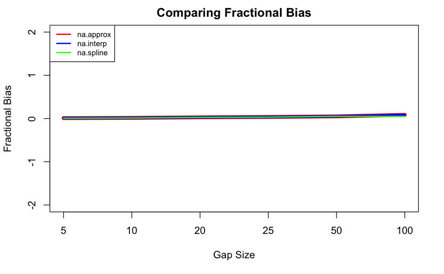

```r
lines(frac_bias_interp, col = 'blue',lwd=4)
lines(frac_bias_spline, col = 'green',lwd=2)
```

```r
cat("\n\nFractional Bias Values for na.approx are:\n",frac_bias_approx)
```

```
Fractional Bias Values for na.approx are:
 0.009926522 0.01524769 0.0279511 0.03631041 0.05021523 0.08542234
```

```r
cat("\n\nFractional Bias Values for na.interp are:\n",frac_bias_interp)
```

```
Fractional Bias Values for na.interp are:
 0.009926522 0.01524769 0.0279511 0.03631041 0.05021523 0.08542234
```

```r
cat("\n\nFractional Bias Values for na.spline are:\n",frac_bias_spline)
```

```
Fractional Bias Values for na.spline are:
 0.007248421 0.01128222 0.02630713 0.0324666 0.05103833 0.0497982
```

Compating mean absolute difference for all three methods

```r
plot(NULL,NULL, xaxt='n', xlim = c(1,6), ylim = c(45,55),xlab = 'Gap Size', ylab = 'Mean Absolute Difference', main = 'Comparing Mean Absolute Difference')
axis(1,at=seq(1:6),labels = l)
```

```r
legend("topleft", c('na.approx', 'na.interp', 'na.spline'), col = c('red','blue','green'),lwd=2,cex=.75)
lines(mad_approx, col = 'red',lwd=4)
```

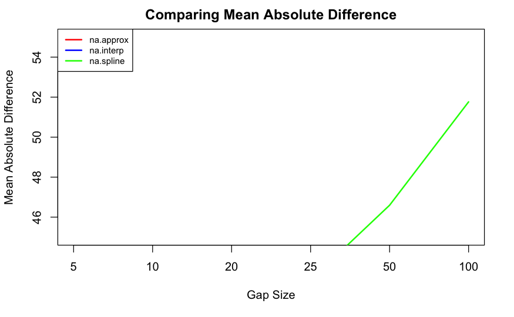

```r
lines(mad_interp, col = 'blue',lwd=2)
lines(mad_spline, col = 'green',lwd=2)
```

```r
cat("\n\nMean Absolute Difference Values for na.approx are:\n",mad_approx)
```

```
Mean Absolute Difference Values for na.approx are:
 39.41913 39.09135 39.52632 39.49848 34.32859 30.14565
```

```r
cat("\n\nMean Absolute Difference Values for na.interp are:\n",mad_interp)
```

```
Mean Absolute Difference Values for na.interp are:
 39.41913 39.09135 39.52632 39.49848 34.32859 30.14565
```

```r
cat("\n\nMean Absolute Difference for na.spline are:\n",mad_spline)
```

```
Mean Absolute Difference for na.spline are:
 40.35526 40.82851 42.2164 42.86114 46.59578 51.76282
```

Compating RMSE for all three methods

```r
plot(NULL,NULL, xaxt='n', xlim = c(1,6), ylim = c(0,10),xlab = 'Gap Size', ylab = 'RMSE', main = 'Comparing RMSE')
axis(1,at=seq(1:6),labels = l)
```

```r
legend("topleft", c('na.approx', 'na.interp', 'na.spline'), col = c('red','blue','green'),lwd=2,cex=.75)
lines(rmse_approx, col = 'red',lwd=4)
```

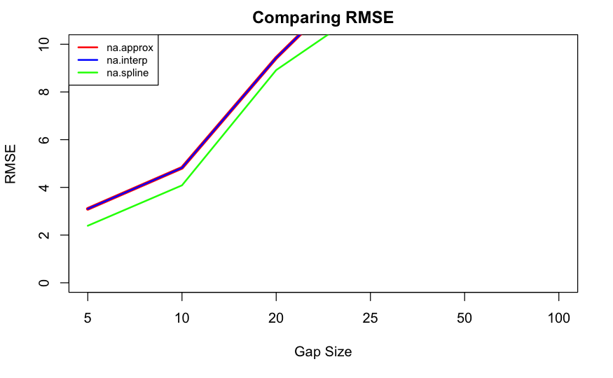

```r
lines(rmse_interp, col = 'blue',lwd=2)
lines(rmse_spline, col = 'green',lwd=2)
```

```r
cat("\n\nRMSE Values for na.approx are:\n",rmse_approx)
```

```
RMSE Values for na.approx are:
 3.099458 4.820467 9.430302 13.3099 20.79507 42.38995
```

```r
cat("\n\nRMSE Values for na.interp are:\n",rmse_interp)
```

```
RMSE Values for na.interp are:
 3.099458 4.820467 9.430302 13.3099 20.79507 42.38995
```

```r
cat("\n\nRMSE for na.spline are:\n",rmse_spline)
```

```
RMSE for na.spline are:
 2.391397 4.08548 8.918298 11.62254 25.00544 34.46513
```

Compating index of agreement for all three methods

```r
plot(NULL,NULL, xaxt='n', xlim = c(1,6), ylim = c(0,1),xlab = 'Gap Size', ylab = 'Index of Agreement', main = 'Comparing Index of Agreement')
axis(1,at=seq(1:6),labels = l)
```

```r
legend("bottomright", c('na.approx', 'na.interp', 'na.spline'), col = c('red','blue','green'),lwd=2,cex=.75)
lines(ioa_approx, col = 'red',lwd=6)
```

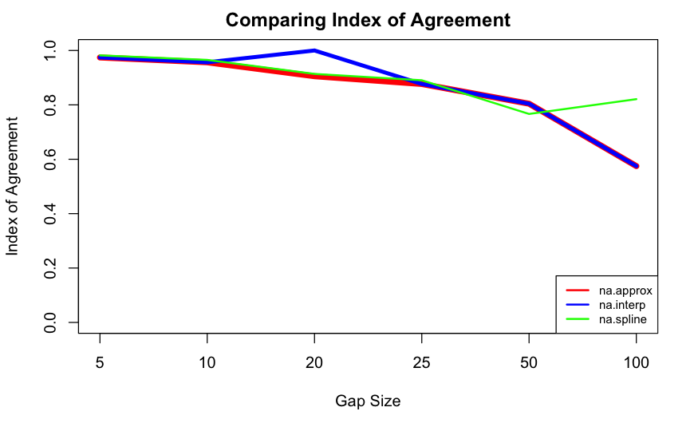

```r
lines(ioa_interp, col = 'blue',lwd=4)
lines(ioa_spline, col = 'green',lwd=2)
```

```r
cat("Index of Agreement Values for na.approx are:\n",ioa_approx)
```

```
Index of Agreement Values for na.approx are:
 0.9743093 0.9565622 0.905405 0.876856 0.8042575 0.5748832
```

```r
cat("\n\nIndex of Agreement Values for na.interp are:\n",ioa_interp)
```

```
Index of Agreement Values for na.interp are:
 0.9743093 0.9565622 1 0.876856 0.8042575 0.5748832
```

```r
cat("\n\nIndex of Agreement Values for na.spline are:\n",ioa_spline)
```

```
Index of Agreement Values for na.spline are:
 0.9820134 0.9653938 0.9138659 0.8904793 0.7665943 0.8210504
```

Boxplots for Fractional Bias

```r
par(mfrow = c(2,3),cex.main=1)
boxplot(fractional_bias_approx_5,fractional_bias_interp_5,fractional_bias_spline_5,
        names = c("approx","interp","spline"),
        col = c("red","blue","green"),
        main = "Gap Size = 5",
        ylim = c(min(fractional_bias_approx_5,fractional_bias_interp_5,fractional_bias_spline_5), max(fractional_bias_approx_5,fractional_bias_interp_5,fractional_bias_spline_5))
        )

boxplot(fractional_bias_approx_10,fractional_bias_interp_10,fractional_bias_spline_10,
        names = c("approx","interp","spline"),
        col = c("red","blue","green"),
        main = "Gap Size = 10",
        ylim = c(min(fractional_bias_approx_10,fractional_bias_interp_10,fractional_bias_spline_10), max(fractional_bias_approx_10,fractional_bias_interp_10,fractional_bias_spline_10))
        )
```

```r
boxplot(fractional_bias_approx_20,fractional_bias_interp_20,fractional_bias_spline_20,
        names = c("approx","interp","spline"),
        col = c("red","blue","green"),
        main = "Gap Size = 20",
        ylim = c(min(fractional_bias_approx_20,fractional_bias_interp_20,fractional_bias_spline_20), max(fractional_bias_approx_20,fractional_bias_interp_20,fractional_bias_spline_20))
        )

boxplot(fractional_bias_approx_25,fractional_bias_interp_25,fractional_bias_spline_25,
        names = c("approx","interp","spline"),
        col = c("red","blue","green"),
        main = "Gap Size = 25",
        ylim = c(min(fractional_bias_approx_25,fractional_bias_interp_25,fractional_bias_spline_25), max(fractional_bias_approx_25,fractional_bias_interp_25,fractional_bias_spline_25))
        )
```

```r
boxplot(fractional_bias_approx_50,fractional_bias_interp_50,fractional_bias_spline_50,
        names = c("approx","interp","spline"),
        col = c("red","blue","green"),
        main = "Gap Size = 50",
        ylim = c(min(fractional_bias_approx_50,fractional_bias_interp_50,fractional_bias_spline_50), max(fractional_bias_approx_50,fractional_bias_interp_50,fractional_bias_spline_50))
        )

boxplot(fractional_bias_approx_100,fractional_bias_interp_100,fractional_bias_spline_100,
        names = c("approx","interp","spline"),
        col = c("red","blue","green"),
        main = "Gap Size = 100",
        ylim = c(min(fractional_bias_approx_100,fractional_bias_interp_100,fractional_bias_spline_100), max(fractional_bias_approx_100,fractional_bias_interp_100,fractional_bias_spline_100))
        )
```

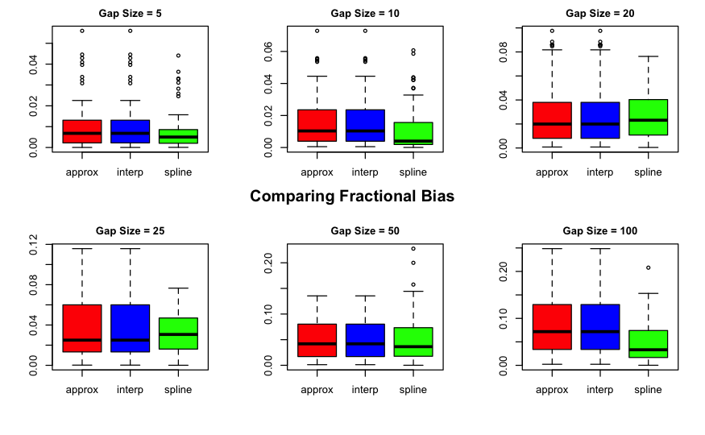

```r
mtext("Comparing Fractional Bias", side=3, line = -16, outer = TRUE,font=2)
```

Boxplots for Index of Agreement

```r
par(mfrow = c(2,3),cex.main=1)
boxplot(ioa_approx_5,ioa_interp_5,ioa_spline_5,
        names = c("approx","interp","spline"),
        col = c("red","blue","green"),
        main = "Gap Size = 5",
        ylim = c(min(ioa_approx_5,ioa_interp_5,ioa_spline_5), max(ioa_approx_5,ioa_interp_5,ioa_spline_5))
        )

boxplot(ioa_approx_10,ioa_interp_10,ioa_spline_10,
        names = c("approx","interp","spline"),
        col = c("red","blue","green"),
        main = "Gap Size = 10",
        ylim = c(min(ioa_approx_10,ioa_interp_10,ioa_spline_10), max(ioa_approx_10,ioa_interp_10,ioa_spline_10))
        )
```

```r
boxplot(ioa_approx_20,ioa_interp_20,ioa_spline_20,
        names = c("approx","interp","spline"),
        col = c("red","blue","green"),
        main = "Gap Size = 20",
        ylim = c(min(ioa_approx_20,ioa_interp_20,ioa_spline_20), max(ioa_approx_20,ioa_interp_20,ioa_spline_20))
        )

boxplot(ioa_approx_25,ioa_interp_25,ioa_spline_25,
        names = c("approx","interp","spline"),
        col = c("red","blue","green"),
        main = "Gap Size = 25",
        ylim = c(min(ioa_approx_25,ioa_interp_25,ioa_spline_25), max(ioa_approx_25,ioa_interp_25,ioa_spline_25))
        )
```

```r
boxplot(ioa_approx_50,ioa_interp_50,ioa_spline_50,
        names = c("approx","interp","spline"),
        col = c("red","blue","green"),
        main = "Gap Size = 50",
        ylim = c(min(ioa_approx_50,ioa_interp_50,ioa_spline_50), max(ioa_approx_50,ioa_interp_50,ioa_spline_50))
        )

boxplot(ioa_approx_100,ioa_interp_100,ioa_spline_100,
        names = c("approx","interp","spline"),
        col = c("red","blue","green"),
        main = "Gap Size = 100",
        ylim = c(min(ioa_approx_100,ioa_interp_100,ioa_spline_100), max(ioa_approx_100,ioa_interp_100,ioa_spline_100))
        )
```

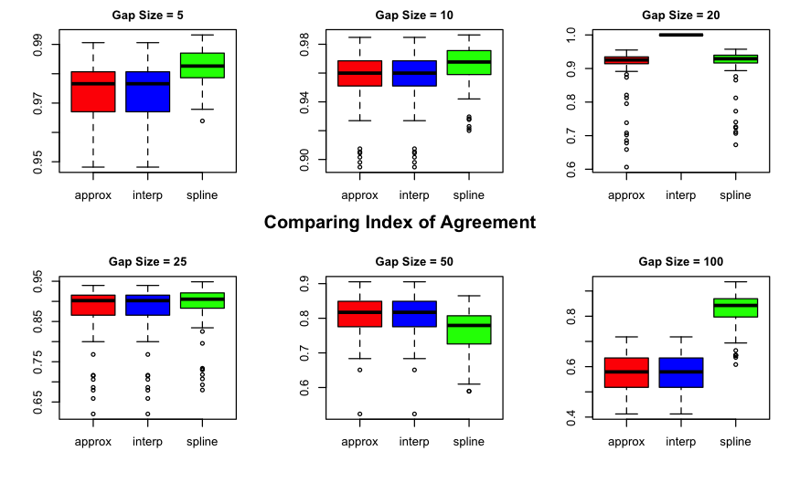

```r
mtext("Comparing Index of Agreement", side=3, line = -16, outer = TRUE,font=2)
```

Boxplots for RMSE

```r
par(mfrow = c(2,3),cex.main=1)
boxplot(rmse_approx_5,rmse_interp_5,rmse_spline_5,
        names = c("approx","interp","spline"),
        col = c("red","blue","green"),
        main = "Gap Size = 5",
        ylim = c(min(rmse_approx_5,rmse_interp_5,rmse_spline_5),max(rmse_approx_5,rmse_interp_5,rmse_spline_5))
        )

boxplot(rmse_approx_10,rmse_interp_10,rmse_spline_10,
        names = c("approx","interp","spline"),
        col = c("red","blue","green"),
        main = "Gap Size = 10",
        ylim = c(min(rmse_approx_10,rmse_interp_10,rmse_spline_10), max(rmse_approx_10,rmse_interp_10,rmse_spline_10))
        )
```

```r
boxplot(rmse_approx_20,rmse_interp_20,rmse_spline_20,
        names = c("approx","interp","spline"),
        col = c("red","blue","green"),
        main = "Gap Size = 20",
        ylim = c(min(rmse_approx_20,rmse_interp_20,rmse_spline_20), max(rmse_approx_20,rmse_interp_20,rmse_spline_20))
        )

boxplot(rmse_approx_25,rmse_interp_25,rmse_spline_25,
        names = c("approx","interp","spline"),
        col = c("red","blue","green"),
        main = "Gap Size = 25",
        ylim = c(min(rmse_approx_25,rmse_interp_25,rmse_spline_25), max(rmse_approx_25,rmse_interp_25,rmse_spline_25))
        )
```

```r
boxplot(rmse_approx_50,rmse_interp_50,rmse_spline_50,
        names = c("approx","interp","spline"),
        col = c("red","blue","green"),
        main = "Gap Size = 50",
        ylim = c(min(rmse_approx_50,rmse_interp_50,rmse_spline_50), max(rmse_approx_50,rmse_interp_50,rmse_spline_50))
        )

boxplot(rmse_approx_100,rmse_interp_100,rmse_spline_100,
        names = c("approx","interp","spline"),
        col = c("red","blue","green"),
        main = "Gap Size = 100",
       ylim = c(min(rmse_approx_100,rmse_interp_100,rmse_spline_100), max(rmse_approx_100,rmse_interp_100,rmse_spline_100))
        )
```

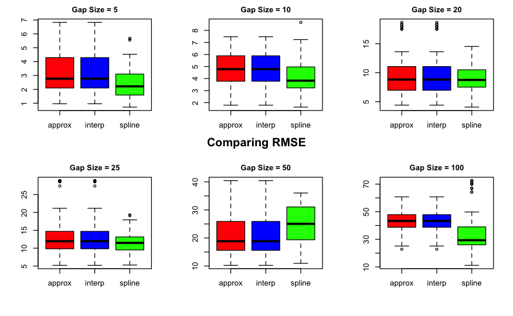

```r
mtext("Comparing RMSE", side=3, line = -16, outer = TRUE,font=2)
```

Boxplots for mean absolute difference

```r
par(mfrow = c(2,3),cex.main=1)
boxplot(mad_approx_5,mad_interp_5,mad_spline_5,
        names = c("approx","interp","spline"),
        col = c("red","blue","green"),
        main = "Gap Size = 5",
        ylim = c(min(mad_approx_5,mad_interp_5,mad_spline_5), max(mad_approx_5,mad_interp_5,mad_spline_5))
        )

boxplot(mad_approx_10,mad_interp_10,mad_spline_10,
        names = c("approx","interp","spline"),
        col = c("red","blue","green"),
        main = "Gap Size = 10",
        ylim = c(min(mad_approx_10,mad_interp_10,mad_spline_10), max(mad_approx_10,mad_interp_10,mad_spline_10))
        )
```

```r
boxplot(mad_approx_20,mad_interp_20,mad_spline_20,
        names = c("approx","interp","spline"),
        col = c("red","blue","green"),
        main = "Gap Size = 20",
        ylim = c(min(mad_approx_20,mad_interp_20,mad_spline_20), max(mad_approx_20,mad_interp_20,mad_spline_20))
        )

boxplot(mad_approx_25,mad_interp_25,mad_spline_25,
        names = c("approx","interp","spline"),
        col = c("red","blue","green"),
        main = "Gap Size = 25",
        ylim = c(min(mad_approx_25,mad_interp_25,mad_spline_25), max(mad_approx_25,mad_interp_25,mad_spline_25))
        )
```

```r
boxplot(mad_approx_50,mad_interp_50,mad_spline_50,
        names = c("approx","interp","spline"),
        col = c("red","blue","green"),
        main = "Gap Size = 50",
        ylim = c(min(mad_approx_50,mad_interp_50,mad_spline_50), max(mad_approx_50,mad_interp_50,mad_spline_50))
        )

boxplot(mad_approx_100,mad_interp_100,mad_spline_100,
        names = c("approx","interp","spline"),
        col = c("red","blue","green"),
        main = "Gap Size = 100",
        ylim = c(min(mad_approx_100,mad_interp_100,mad_spline_100), max(mad_approx_100,mad_interp_100,mad_spline_100))
        )
```

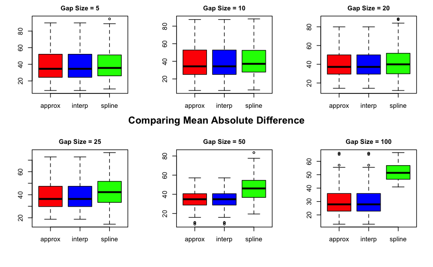

```r
mtext("Comparing Mean Absolute Difference", side=3, line = -16, outer = TRUE,font=2)
```